# HW 1: Исследование данных об аэропортах

Барышев Матвей, mibaryshev

## Задача

на основе данных (и выданных вопросов) постараться выяснить:

- какие проблемы есть в авиаперевозках
- какие улучшения можно предложить на основе выводов по данным

#### Загрузка данных и преобразование

| id | questions |
| --- | --- |
| 1 | -Пишут ли люди более добрые отзывы на аэропорты в выходные (доброту определяем через overall_rating) |
| 2 | -Пользователи каких стран чаще употребляют слово “good” (но не “not good”) в отрицательных отзывах на лаунж-зоны? Т.е. находят что-то хорошее, но в целом не рекомендуют. |
| 3 | -Какие аэропорты рекомендуют чаще, те, в которых есть лаунжи бизнесс-класса, или те, в которых их нет? |

В таблице airport столбец date был приведён к типу Date и добавлен столбец week_day обозначающий день недели.

### Вопросы

#### Вопрос 1

**Вопрос:** Пишут ли люди более добрые отзывы на аэропорты в выходные (доброту определяем через overall_rating).

**Данные:** для ответа на вопрос нужны таблицы airport.

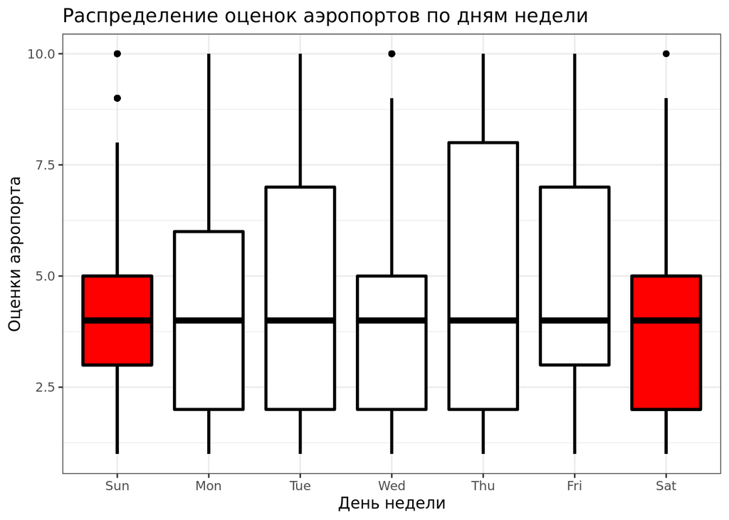

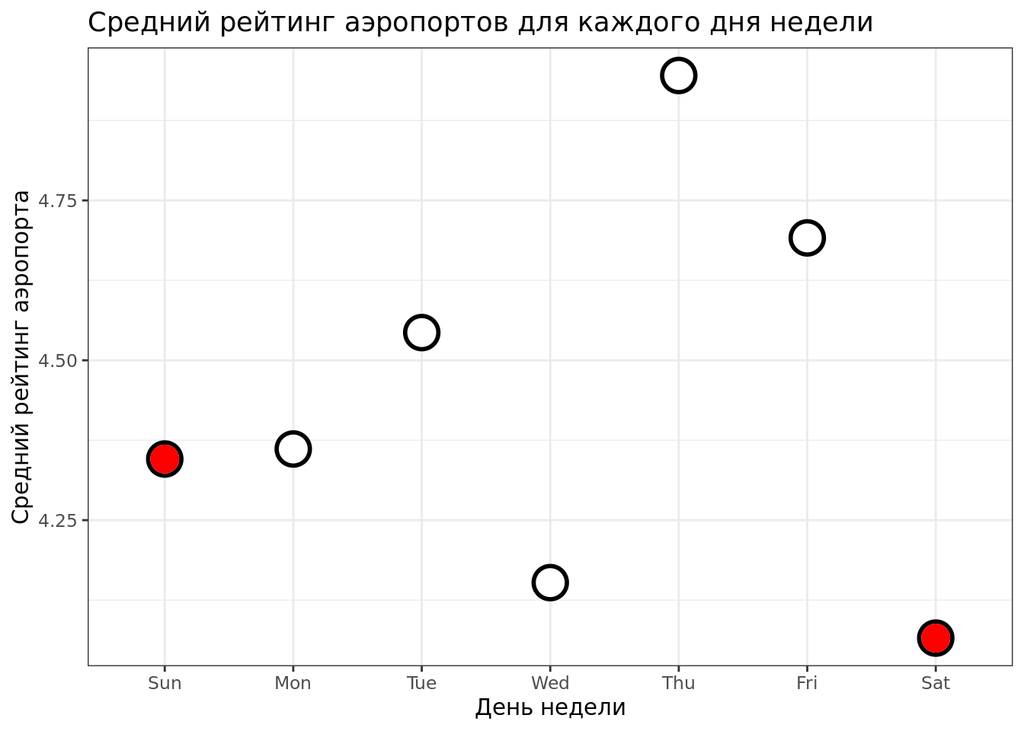

**Ответ:** Люди не пишут более добрые отзывы в выходные.

#### Вопрос 2

**Вопрос:** Пользователи каких стран чаще употребляют слово “good” (но не “not good”) в отрицательных отзывах на лаунж-зоны? Т.е. находят что-то хорошее, но в целом не рекомендуют.

**Данные:** для ответа на вопрос нужны таблицы lounge.

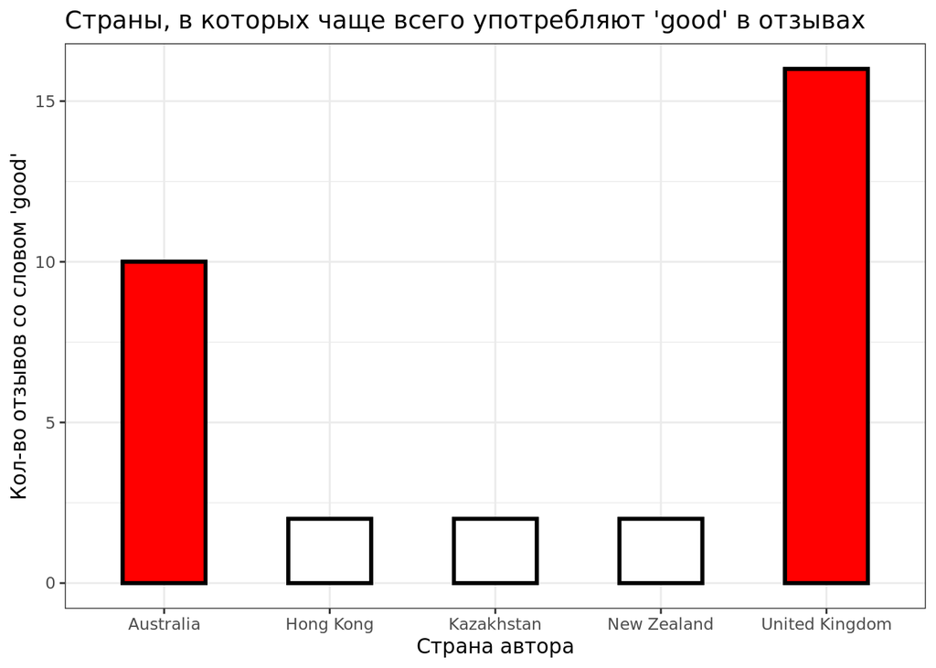

**Ответ:** Пользователи из Великобритании употребляют слово “good” (но не “not good”) в отрицательных отзывах на лаунж-зоны чаще всех. Также пользователи из Австралии употребляют “good” довольно часто.

**Вывод:** Возможно, пользователи из данных стран стараются быть более объективными, более тщательно подходят к написанию отзыва и стараются выделять не только отрицательные аспекты, но и положительные.

#### Вопрос 3

**Вопрос:** Какие аэропорты рекомендуют чаще, те, в которых есть лаунжи бизнесс-класса, или те, в которых их нет?

**Данные:** для ответа на вопрос нужны таблицы lounge, airport.

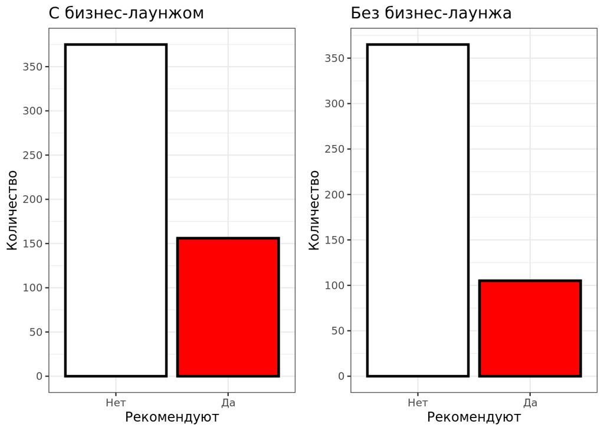

**Ответ:** Аэропорты, в которых есть бизнес-лаунж, рекомендуют чаще.

**Вывод:** Из графиков видно, что наличие бизнес-лаунжа в аэропорту увеличивает шанс того, что пользователь порекомендует аэропорт. Количество рекомендаций на аэропорты с бизнес-лаунжом в ~1.5 раза больше, чем на аэропорты без бизнес-лаунжа

### Дэшборд

Полученные выводы обобщены в виде дэшборда со следующими элементами

**Элемент 2:** - вид: график - ответ на вопрос: 1 - обоснование: точечный график ярко отображает различия в средней оценке в каждый из дней недели.

**Элемент 3:** - вид: график - ответ на вопрос: 3 - обоснование: из столбчатой диаграммы можно легко увидеть, что количество рекомендаций у аэропортов с бизнес-лаунжами больше, чем у аэропортов без него.

**Элемент 4:** - вид: числа - ответ на вопрос: 3 - обоснование: числа показывают соотношения рекомендательных отзывов к общему числу аэропортов с/без бизнес-лаунжа.